# Capital Study: Data Cleaning

Group 10

```r
#loading for analysis prepared data table
capital <- read.csv('~/CS-SS20/Experimental_Psychology_Lab/Final_Project/XPLab2020_FinalProject/pilot/Capital_Study/capital_data_cleaning/capital_data.csv')

capital
```

```
##    unique_trial_id subject_id   RT correctness mousetrackingDuration
## 1                1       1993 1550     Correct                  1518
## 2                4       1993 1678     Correct                  1577
## 3                5       1993 1010     Correct                   931
## 4                6       1993 1062     Correct                   986
## 5               11       1993 1532     Correct                  1414
## 6               12       1992 1392     Correct                  1167
## 7               13       1992 1362     Correct                  1291
## 8               15       1992 1336     Correct                  1180
## 9               16       1992 1899     Correct                  1799
## 10              17       1992 2169     Correct                  2067
## 11              18       1992 1456     Correct                  1342
## 12              19       1992 1234     Correct                  1030
## 13              23       1992 1550     Correct                  1430
## 14              24       1991 2937     Correct                  2620
```

[output cut: 153 more lines]

## Data Analysis - Original Study

For the main trials of our experiment we hold the following research hypotheses:

H1: The area under the curve (AUC) is larger for atypical trials compared to typical trials.

H2: The maximal absolute deviation (MAD) is larger for atypical trials compared to typical trials.

H3: Movement duration is longer for atypical trials compared to typical trials.

H4: The likelihood of obtaining different cluster types depends on the experimental conditions.

H5: The total categorisation response time is longer for atypical trials compared to typical trials.

H6: The movement initiation latency is longer for atypical trials compared to typical trials.

H7: The distance travelled in pixels is longer for atypical trials compared to typical trials.

# REGRESSION MODELS

Hypothesis 1

```r
#Taking absolute AUC values, since negative AUC make no sense
capital$AUC_abs = abs(capital$AUC)
capital$AUC_abs_s = my_scale(capital$AUC_abs)

#informative prior
prior_hypo1 <- c(
  #priors for all fixed effects (trial_type)
  set_prior("student_t(3, -1, 2)", class = "sd"),
  #prior for the Intercept
  set_prior("student_t(3, 0, 2)", class = "Intercept"),
  #prior for all SDs including the varying intercepts and slopes
  set_prior("student_t(3, -2, 2)", class = "sigma")
)


model_hypo1 = brm(
  AUC_abs_s ~ trial_type +
    (trial_type || subject_id)+
    (1 |exemplar),
  control=list(adapt_delta=0.99, max_treedepth=15),
  data = capital,
  prior = prior_hypo1
  )

model_hypo1
```

```
##  Family: gaussian
##   Links: mu = identity; sigma = identity
## Formula: AUC_abs_s ~ trial_type + (trial_type || subject_id) + (1 | exemplar)
##    Data: capital (Number of observations: 41)
## Samples: 4 chains, each with iter = 2000; warmup = 1000; thin = 1;
##          total post-warmup samples = 4000
##
## Group-Level Effects:
## ~exemplar (Number of levels: 12)
##               Estimate Est.Error l-95% CI u-95% CI Rhat Bulk_ESS Tail_ESS
## sd(Intercept)     0.38      0.24     0.02     0.94 1.00     1238     1897
##
## ~subject_id (Number of levels: 5)
##                       Estimate Est.Error l-95% CI u-95% CI Rhat Bulk_ESS
## sd(Intercept)             0.56      0.47     0.02     1.75 1.00     1145
## sd(trial_typeTypical)     0.95      0.60     0.12     2.40 1.01      921
##                       Tail_ESS
## sd(Intercept)             1683
## sd(trial_typeTypical)      959
##
## Population-Level Effects:
##                   Estimate Est.Error l-95% CI u-95% CI Rhat Bulk_ESS Tail_ESS
## Intercept             0.40      0.48    -0.55     1.39 1.00     3073     2321
## trial_typeTypical    -0.47      0.63    -1.76     0.82 1.00     2050     1790
##
## Family Specific Parameters:
##       Estimate Est.Error l-95% CI u-95% CI Rhat Bulk_ESS Tail_ESS
## sigma     0.82      0.13     0.61     1.10 1.00     1399     1980
##
## Samples were drawn using sampling(NUTS). For each parameter, Bulk_ESS
## and Tail_ESS are effective sample size measures, and Rhat is the potential
## scale reduction factor on split chains (at convergence, Rhat = 1).
```

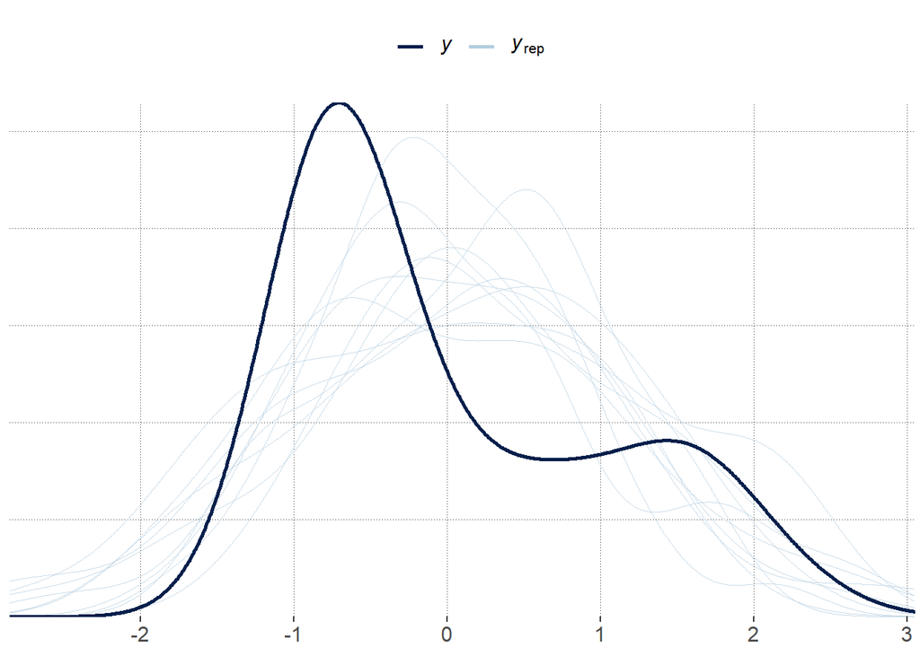

```r
#fitting the model to the actual data
pp_check(model_hypo1)
```

```r
# Extract the posteriors
posteriors1_trial_type <- model_hypo1 %>%
  spread_draws(b_Intercept,
               b_trial_typeTypical) %>%
  # calculate posteriors for each individual level
  mutate(Atypical = b_Intercept,
         Typical = b_Intercept + b_trial_typeTypical) %>%
  select(Atypical, Typical) %>%
  gather(key = "parameter", value = "posterior") %>%
  group_by(parameter) %>%
  summarise(mean_posterior = mean(posterior),
            `95lowerCrI` = HDInterval::hdi(posterior, credMass = 0.90)[1],
            `95higherCrI` = HDInterval::hdi(posterior, credMass = 0.90)[2])

posteriors1_trial_type
```

```
## # A tibble: 2 x 4
##   parameter mean_posterior `95lowerCrI` `95higherCrI`
##   <chr>              <dbl>        <dbl>         <dbl>
## 1 Atypical          0.399        -0.358         1.15
## 2 Typical          -0.0689       -0.988         0.900
```

```r
# Extract the posteriors
posteriors1 <- model_hypo1 %>%
  spread_draws(b_trial_typeTypical) %>%
  select(b_trial_typeTypical) %>%
  gather(key = "parameter", value = "posterior")


posteriors1
```

```
## # A tibble: 4,000 x 2
##    parameter           posterior
##    <chr>                   <dbl>
##  1 b_trial_typeTypical    -0.329
##  2 b_trial_typeTypical    -0.881
##  3 b_trial_typeTypical    -0.449
##  4 b_trial_typeTypical    -0.328
##  5 b_trial_typeTypical    -0.791
##  6 b_trial_typeTypical    -0.500
##  7 b_trial_typeTypical    -0.873
##  8 b_trial_typeTypical    -0.874
##  9 b_trial_typeTypical    -0.809
## 10 b_trial_typeTypical    -0.449
## # ... with 3,990 more rows
```

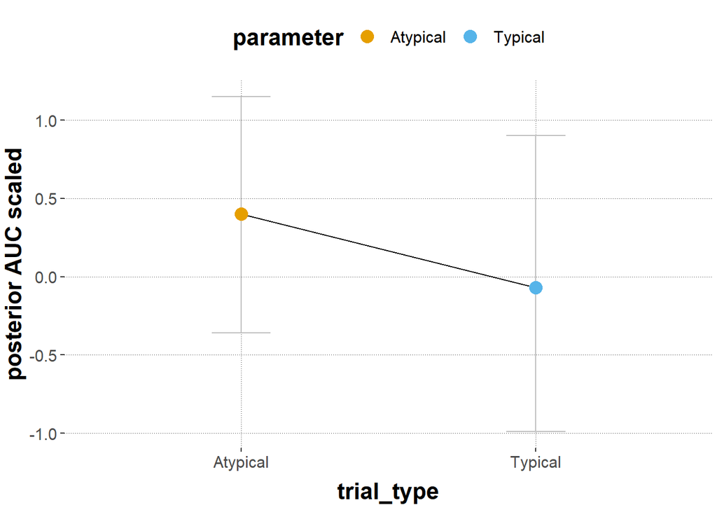

```r
# plot
ggplot(data = posteriors1_trial_type,
       aes(x = parameter, y = mean_posterior,
           color = parameter, fill = parameter)) +
  geom_errorbar(aes(ymin = `95lowerCrI`, ymax = `95higherCrI`),
                width = 0.2, color = "grey") +
  geom_line(aes(group = 1), color = "black") +
  geom_point(size = 4) +
  labs(x = "trial_type",
       y = "posterior AUC scaled")
```

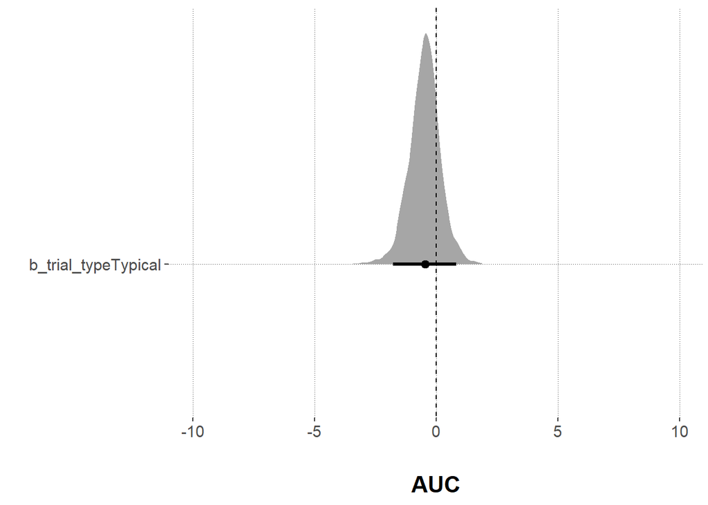

```r
# plot the regression coefficients
  ggplot(posteriors1, aes(x = posterior, y = parameter)) +
    # plot density
    geom_halfeyeh(.width = 0.95) +
    # add axes titles
    xlab("\nAUC") +
    ylab("") +
    # adjust the x-axis
    scale_x_continuous(limits = c(-10,10)) +
    # add line for the value zero
    geom_segment(x = 0, xend = 0, y = Inf, yend = -Inf,
                 lty = "dashed")
```

Results: Absolute, scaled AUC values are higher for Atypical than Typical trial types, due to the negative slope going from the reference level (Atypical) to the Typical trial type. The credible interval of the coefficient trial_typeTypical includes 0, wherefore there is no compelling evidence for the hypothesis to hold true.

Hypothesis 2

```r
#Taking absolute AUC values, since negative AUC make no sense
capital$MAD_abs = abs(capital$MAD)
capital$MAD_abs_s = my_scale(capital$MAD_abs)

#informative prior
prior_hypo2 <- c(
  #priors for all fixed effects (trial_type)
  set_prior("student_t(3, 0, 2)", class = "sigma"),
  #prior for the Intercept
  set_prior("student_t(3, -1, 2)", class = "Intercept"),
  #prior for all SDs including the varying intercepts and slopes
  set_prior("student_t(3, 0, 2)", class = "sd")
)

#by-subject_id varying intercepts and varying
#slope, without slope/intercept correlation
#by-exemplar varying intercept
model_hypo2 = brm(
  MAD_abs_s ~ trial_type +
    (trial_type || subject_id)+
    (1|exemplar),
  control=list(adapt_delta=0.99, max_treedepth=15),
  data = capital,
  prior = prior_hypo2
  )

model_hypo2
```

```
##  Family: gaussian
##   Links: mu = identity; sigma = identity
## Formula: MAD_abs_s ~ trial_type + (trial_type || subject_id) + (1 | exemplar)
##    Data: capital (Number of observations: 41)
## Samples: 4 chains, each with iter = 2000; warmup = 1000; thin = 1;
##          total post-warmup samples = 4000
##
## Group-Level Effects:
## ~exemplar (Number of levels: 12)
##               Estimate Est.Error l-95% CI u-95% CI Rhat Bulk_ESS Tail_ESS
## sd(Intercept)     0.56      0.27     0.07     1.14 1.00      935      669
##
## ~subject_id (Number of levels: 5)
##                       Estimate Est.Error l-95% CI u-95% CI Rhat Bulk_ESS
## sd(Intercept)             0.40      0.38     0.01     1.37 1.00     1323
## sd(trial_typeTypical)     0.68      0.50     0.04     1.94 1.00     1110
##                       Tail_ESS
## sd(Intercept)             1485
## sd(trial_typeTypical)     1321
##
## Population-Level Effects:
##                   Estimate Est.Error l-95% CI u-95% CI Rhat Bulk_ESS Tail_ESS
## Intercept             0.35      0.45    -0.54     1.30 1.00     2505     2210
## trial_typeTypical    -0.47      0.61    -1.64     0.73 1.00     1248     1603
##
## Family Specific Parameters:
##       Estimate Est.Error l-95% CI u-95% CI Rhat Bulk_ESS Tail_ESS
## sigma     0.80      0.13     0.60     1.08 1.00     1626     2580
##
## Samples were drawn using sampling(NUTS). For each parameter, Bulk_ESS
## and Tail_ESS are effective sample size measures, and Rhat is the potential
## scale reduction factor on split chains (at convergence, Rhat = 1).
```

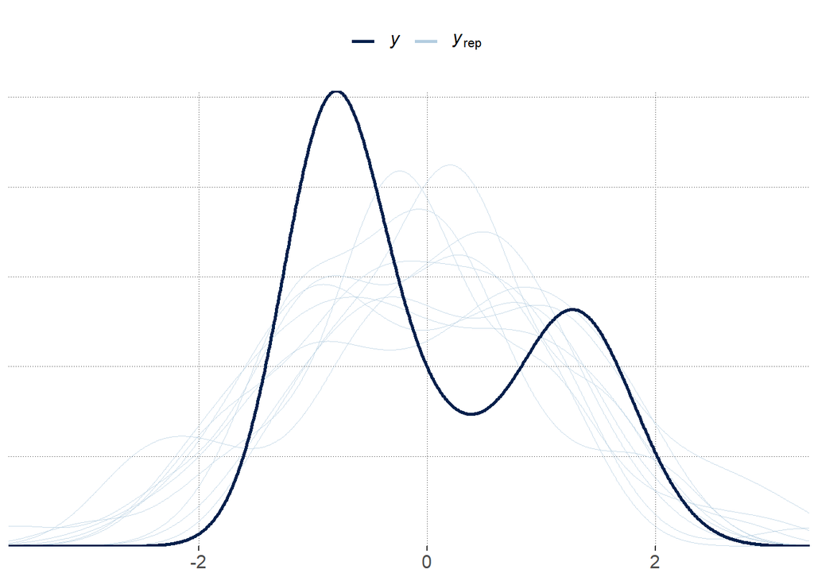

```r
#fitting the model to the actual data
pp_check(model_hypo2)
```

```r
# Extract the posteriors
posteriors2_trial_type <- model_hypo2 %>%
  spread_draws(b_Intercept,
               b_trial_typeTypical) %>%
  # calculate posteriors for each individual level
  mutate(Atypical = b_Intercept,
         Typical = b_Intercept + b_trial_typeTypical) %>%
  select(Atypical, Typical) %>%
  gather(key = "parameter", value = "posterior") %>%
  group_by(parameter) %>%
  summarise(mean_posterior = mean(posterior),
            `95lowerCrI` = HDInterval::hdi(posterior, credMass = 0.90)[1],
            `95higherCrI` = HDInterval::hdi(posterior, credMass = 0.90)[2])

posteriors2_trial_type
```

```
## # A tibble: 2 x 4
##   parameter mean_posterior `95lowerCrI` `95higherCrI`
##   <chr>              <dbl>        <dbl>         <dbl>
## 1 Atypical           0.348       -0.372         1.12
## 2 Typical           -0.123       -0.925         0.710
```

```r
# Extract the posteriors
posteriors2 <- model_hypo2 %>%
  spread_draws(b_trial_typeTypical) %>%
  select(b_trial_typeTypical) %>%
  gather(key = "parameter", value = "posterior")


posteriors2
```

```
## # A tibble: 4,000 x 2
##    parameter           posterior
##    <chr>                   <dbl>
##  1 b_trial_typeTypical    -1.06
##  2 b_trial_typeTypical    -1.16
##  3 b_trial_typeTypical    -0.763
##  4 b_trial_typeTypical    -1.64
##  5 b_trial_typeTypical    -0.955
##  6 b_trial_typeTypical    -0.631
##  7 b_trial_typeTypical    -1.56
##  8 b_trial_typeTypical    -1.38
##  9 b_trial_typeTypical    -1.84
## 10 b_trial_typeTypical    -1.16
## # ... with 3,990 more rows
```

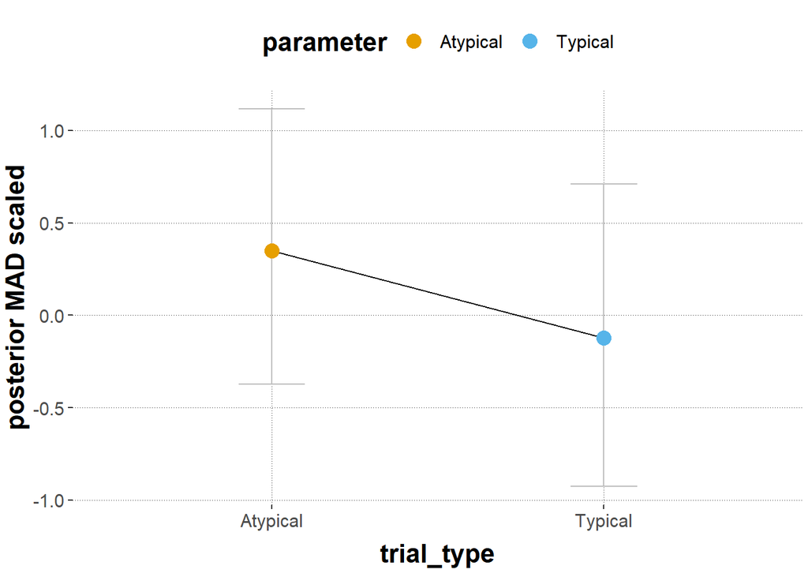

```r
# plot
ggplot(data = posteriors2_trial_type,
       aes(x = parameter, y = mean_posterior,
           color = parameter, fill = parameter)) +
  geom_errorbar(aes(ymin = `95lowerCrI`, ymax = `95higherCrI`),
                width = 0.2, color = "grey") +
  geom_line(aes(group = 1), color = "black") +
  geom_point(size = 4) +
  labs(x = "trial_type",
       y = "posterior MAD scaled")
```

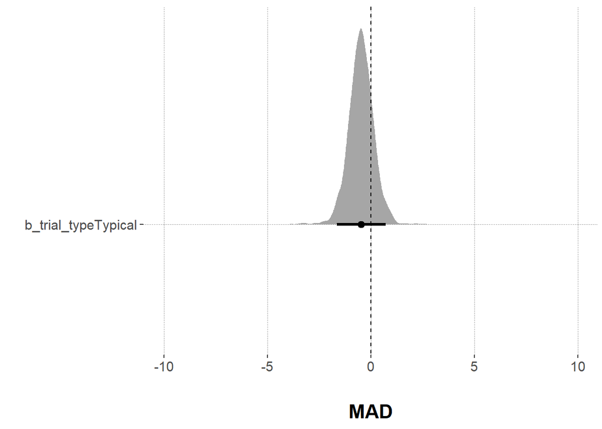

```r
# plot the regression coefficients
  ggplot(posteriors2, aes(x = posterior, y = parameter)) +
    # plot density
    geom_halfeyeh(.width = 0.95) +
    # add axes titles
    xlab("\nMAD") +
    ylab("") +
    # adjust the x-axis
    scale_x_continuous(limits = c(-10,10)) +
    # add line for the value zero
    geom_segment(x = 0, xend = 0, y = Inf, yend = -Inf,
                 lty = "dashed")
```

Results: Absolute scaled MAD values are higher for Atypical than Typical trial types, due to the negative slope going from the reference level (Atypical) to the Typical trial type. The credible interval of the coefficient trial_typeTypical includes 0, wherefore there is no compelling evidence for the hypothesis to hold true.

Hypothesis 3

```r
capital$mousetrackingDuration_s = my_scale(capital$mousetrackingDuration)

#informative prior
prior_hypo3 <- c(
  #priors for all fixed effects (trial_type)
  set_prior("student_t(3, 0, 2)", class = "sigma"),
  #prior for the Intercept
  set_prior("student_t(3, -0.5, 2)", class = "Intercept"),
  #prior for all SDs including the varying intercepts and slopes
  set_prior("student_t(3, 0, 2)", class = "sd")
)

#by-subject_id varying intercepts and varying
#slope, without slope/intercept correlation
#by-exemplar varying intercept
model_hypo3 = brm(
  mousetrackingDuration_s ~ trial_type +
    (trial_type || subject_id)+
    (1|exemplar),
  control=list(adapt_delta=0.99, max_treedepth=15),
  data = capital,
  prior = prior_hypo3
  )

model_hypo3
```

```
##  Family: gaussian
##   Links: mu = identity; sigma = identity
## Formula: mousetrackingDuration_s ~ trial_type + (trial_type || subject_id) + (1 | exemplar)
##    Data: capital (Number of observations: 41)
## Samples: 4 chains, each with iter = 2000; warmup = 1000; thin = 1;
##          total post-warmup samples = 4000
##
## Group-Level Effects:
## ~exemplar (Number of levels: 12)
##               Estimate Est.Error l-95% CI u-95% CI Rhat Bulk_ESS Tail_ESS
## sd(Intercept)     1.36      0.38     0.78     2.31 1.00     1067     1758
##
## ~subject_id (Number of levels: 5)
##                       Estimate Est.Error l-95% CI u-95% CI Rhat Bulk_ESS
## sd(Intercept)             0.32      0.33     0.01     1.18 1.01      707
## sd(trial_typeTypical)     0.27      0.30     0.01     1.06 1.01      646
##                       Tail_ESS
## sd(Intercept)             1457
## sd(trial_typeTypical)     1466
##
## Population-Level Effects:
##                   Estimate Est.Error l-95% CI u-95% CI Rhat Bulk_ESS Tail_ESS
## Intercept             1.23      0.68    -0.12     2.59 1.00     1627     2362
## trial_typeTypical    -1.56      0.87    -3.28     0.09 1.00     1310     1925
##
## Family Specific Parameters:
##       Estimate Est.Error l-95% CI u-95% CI Rhat Bulk_ESS Tail_ESS
## sigma     0.52      0.09     0.38     0.71 1.00     1375     2181
##
## Samples were drawn using sampling(NUTS). For each parameter, Bulk_ESS
## and Tail_ESS are effective sample size measures, and Rhat is the potential
## scale reduction factor on split chains (at convergence, Rhat = 1).
```

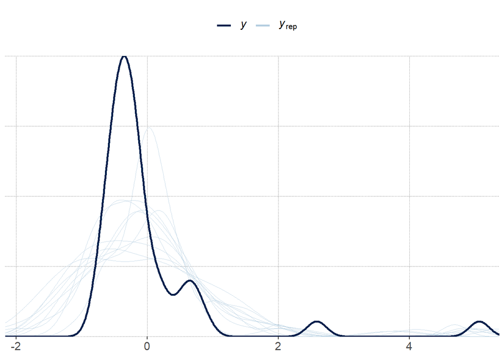

```r
#fitting the model to the actual data
pp_check(model_hypo3)
```

```r
# Extract the posteriors
posteriors3_trial_type <- model_hypo3 %>%
  spread_draws(b_Intercept,
               b_trial_typeTypical) %>%
  # calculate posteriors for each individual level
  mutate(Atypical = b_Intercept,
         Typical = b_Intercept + b_trial_typeTypical) %>%
  select(Atypical, Typical) %>%
  gather(key = "parameter", value = "posterior") %>%
  group_by(parameter) %>%
  summarise(mean_posterior = mean(posterior),
            `95lowerCrI` = HDInterval::hdi(posterior, credMass = 0.90)[1],
            `95higherCrI` = HDInterval::hdi(posterior, credMass = 0.90)[2])

posteriors3_trial_type
```

```
## # A tibble: 2 x 4
##   parameter mean_posterior `95lowerCrI` `95higherCrI`
##   <chr>              <dbl>        <dbl>         <dbl>
## 1 Atypical           1.23         0.156         2.33
## 2 Typical           -0.332       -1.28          0.614
```

```r
# Extract the posteriors
posteriors3 <- model_hypo3 %>%
  spread_draws(b_trial_typeTypical) %>%
  select(b_trial_typeTypical) %>%
  gather(key = "parameter", value = "posterior")


posteriors3
```

```
## # A tibble: 4,000 x 2
##    parameter           posterior
##    <chr>                   <dbl>
##  1 b_trial_typeTypical     -2.18
##  2 b_trial_typeTypical     -2.48
##  3 b_trial_typeTypical     -2.18
##  4 b_trial_typeTypical     -2.20
##  5 b_trial_typeTypical     -2.17
##  6 b_trial_typeTypical     -2.06
##  7 b_trial_typeTypical     -2.26
##  8 b_trial_typeTypical     -2.21
##  9 b_trial_typeTypical     -1.79
## 10 b_trial_typeTypical     -2.05
## # ... with 3,990 more rows
```

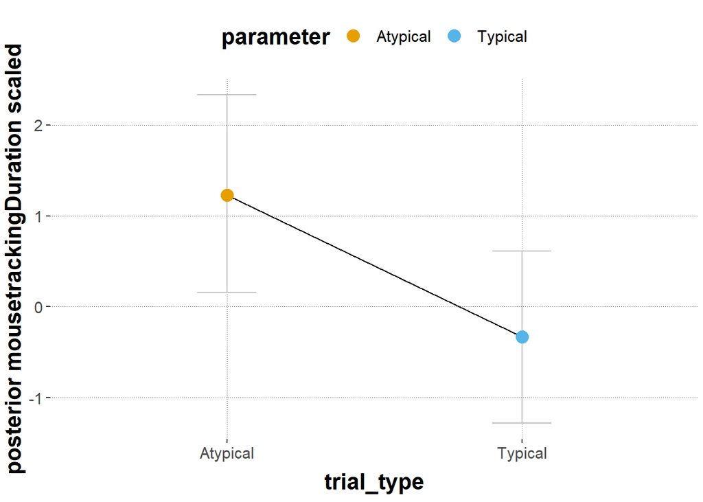

```r
# plot
ggplot(data = posteriors3_trial_type,
       aes(x = parameter, y = mean_posterior,
           color = parameter, fill = parameter)) +
  geom_errorbar(aes(ymin = `95lowerCrI`, ymax = `95higherCrI`),
                width = 0.2, color = "grey") +
  geom_line(aes(group = 1), color = "black") +
  geom_point(size = 4) +
  labs(x = "trial_type",
       y = "posterior mousetrackingDuration scaled")
```

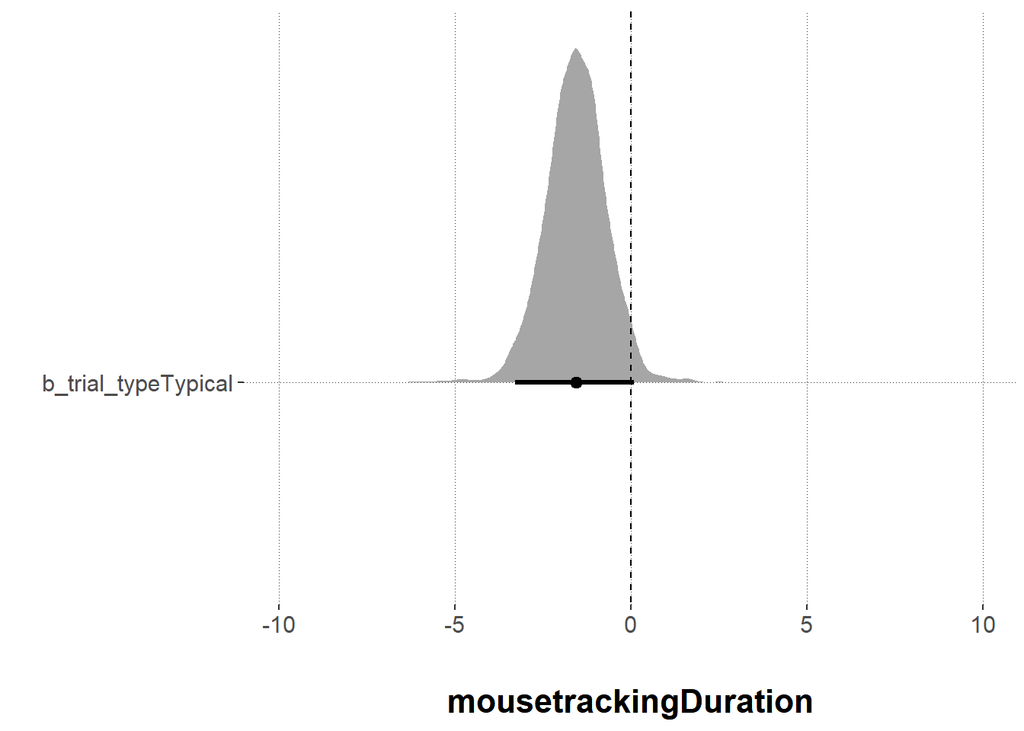

```r
# plot the regression coefficients
  ggplot(posteriors3, aes(x = posterior, y = parameter)) +
    # plot density
    geom_halfeyeh(.width = 0.95) +
    # add axes titles
    xlab("\nmousetrackingDuration") +
    ylab("") +
    # adjust the x-axis
    scale_x_continuous(limits = c(-10,10)) +
    # add line for the value zero
    geom_segment(x = 0, xend = 0, y = Inf, yend = -Inf,
                 lty = "dashed")
```

Results: Scaled mousetracking Duration values are higher for Atypical than Typical trial types, due to the negative slope going from the reference level (Atypical) to the Typical trial type. The credible interval of the coefficient trial_typeTypical includes 0, wherefore there is no compelling evidence for the hypothesis to hold true.

Hypothesis 4

```r
capital$factor_prototype_label <- factor(capital$prototype_label)

#multinomial logistic regression model
#by-subject_id varying intercepts and varying
#slope, without slope/intercept correlation
#by-exemplar varying intercept
model_hypo4 <- brm(
  factor_prototype_label ~ trial_type +
    (trial_type || subject_id)+
    (1|exemplar),
  data = capital,
  family = categorical(link = "logit", refcat = NULL)
)

model_hypo4
```

```
##  Family: categorical
##   Links: mucurved = logit; mudCoM = logit; mudCoM2 = logit; mustraight = logit
## Formula: factor_prototype_label ~ trial_type + (trial_type || subject_id) + (1 | exemplar)
##    Data: capital (Number of observations: 41)
## Samples: 4 chains, each with iter = 2000; warmup = 1000; thin = 1;
##          total post-warmup samples = 4000
##
## Group-Level Effects:
## ~exemplar (Number of levels: 12)
##                          Estimate Est.Error l-95% CI u-95% CI Rhat Bulk_ESS
## sd(mucurved_Intercept)       2.13      1.48     0.13     5.64 1.00     1800
## sd(mudCoM_Intercept)         3.03      2.16     0.18     8.41 1.00     1346
## sd(mudCoM2_Intercept)        2.07      1.82     0.08     6.35 1.00     3013
## sd(mustraight_Intercept)     2.53      1.49     0.25     6.08 1.00     1354
##                          Tail_ESS
## sd(mucurved_Intercept)       1988
## sd(mudCoM_Intercept)         1561
## sd(mudCoM2_Intercept)        2488
## sd(mustraight_Intercept)     1393
##
## ~subject_id (Number of levels: 5)
##                                  Estimate Est.Error l-95% CI u-95% CI Rhat
## sd(mucurved_Intercept)               1.83      1.57     0.08     5.85 1.00
## sd(mucurved_trial_typeTypical)       1.86      1.62     0.07     5.90 1.00
## sd(mudCoM_Intercept)                 2.75      1.97     0.18     7.39 1.00
## sd(mudCoM_trial_typeTypical)         2.29      2.03     0.10     7.22 1.00
## sd(mudCoM2_Intercept)                2.44      2.40     0.09     8.61 1.00
## sd(mudCoM2_trial_typeTypical)        2.09      2.18     0.07     7.69 1.00
## sd(mustraight_Intercept)             2.33      1.79     0.11     6.67 1.00
## sd(mustraight_trial_typeTypical)     3.46      2.54     0.20     9.81 1.00
##                                  Bulk_ESS Tail_ESS
## sd(mucurved_Intercept)               2914     2815
## sd(mucurved_trial_typeTypical)       2978     2711
## sd(mudCoM_Intercept)                 2281     1410
## sd(mudCoM_trial_typeTypical)         2774     2787
## sd(mudCoM2_Intercept)                2414     1916
## sd(mudCoM2_trial_typeTypical)        3637     2135
## sd(mustraight_Intercept)             1818     1990
## sd(mustraight_trial_typeTypical)     2014     1585
##
```

[output cut: 8 more lines]

```
## mudCoM2_trial_typeTypical       -5.34      5.73   -19.64     3.36 1.00     2020
## mustraight_trial_typeTypical     1.94      3.07    -3.84     8.60 1.00     2219
##                              Tail_ESS
## mucurved_Intercept               1136
## mudCoM_Intercept                 2784
## mudCoM2_Intercept                2803
## mustraight_Intercept             2548
## mucurved_trial_typeTypical       1259
## mudCoM_trial_typeTypical         2776
## mudCoM2_trial_typeTypical         927
## mustraight_trial_typeTypical     2327
##
## Samples were drawn using sampling(NUTS). For each parameter, Bulk_ESS
## and Tail_ESS are effective sample size measures, and Rhat is the potential
## scale reduction factor on split chains (at convergence, Rhat = 1).
```

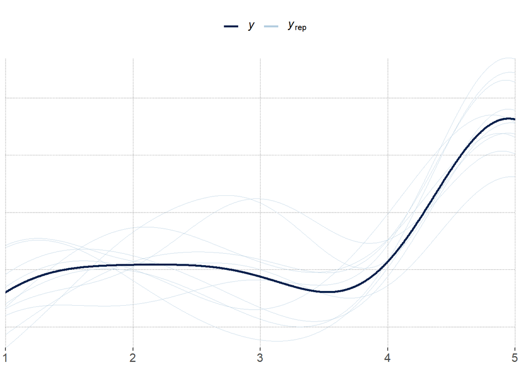

```r
#fitting model to the actual data
pp_check(model_hypo4)
```

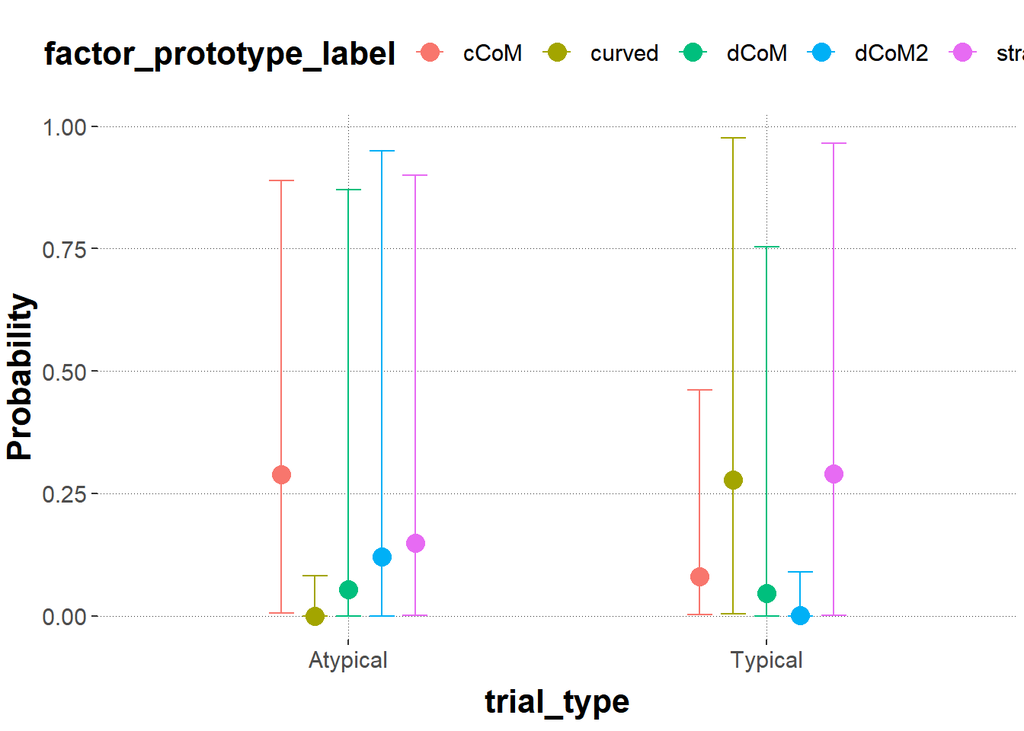

```r
#plotting marginal probabilities
marginal_effects(model_hypo4, "trial_type", categorical = TRUE)
```

```r
#extracting posteriors
predicted_hypo4 <- model_hypo4 %>%
  spread_draws(b_mucurved_Intercept,
               b_mudCoM_Intercept,
               b_mustraight_Intercept,
               b_mudCoM2_Intercept,
               b_mucurved_trial_typeTypical,
               b_mudCoM_trial_typeTypical,
               b_mustraight_trial_typeTypical,
               b_mudCoM2_trial_typeTypical) %>%
  # mutating the parameters with their coefficient combination
  mutate(curved_Atypical = plogis(b_mucurved_Intercept),
         curved_Typical = plogis(b_mucurved_Intercept + b_mucurved_trial_typeTypical),
         dCoM_Atypical = plogis(b_mudCoM_Intercept),
          dCoM_Typical = plogis(b_mudCoM_Intercept + b_mudCoM_trial_typeTypical),
         straight_Atypical = plogis(b_mustraight_Intercept),
         straight_Typical = plogis(b_mustraight_Intercept + b_mustraight_trial_typeTypical),
         dCoM2_Atypical = plogis(b_mudCoM2_Intercept),
          dCoM2_Typical = plogis(b_mudCoM2_Intercept + b_mudCoM2_trial_typeTypical),
         cCoM_Atypical = plogis(b_mucurved_Intercept + b_mudCoM_Intercept + b_mustraight_Intercept + b_mudCoM2_Intercept),
         cCoM_Typical = plogis(b_mucurved_Intercept + b_mudCoM_Intercept + b_mustraight_Intercept + b_mucurved_trial_typeTypical +
                             b_mudCoM_trial_typeTypical + b_mustraight_trial_typeTypical + b_mudCoM2_Intercept + b_mudCoM2_trial_typeTypical)) %>%
  select(curved_Atypical, curved_Typical, dCoM_Atypical, dCoM_Typical, dCoM2_Atypical, dCoM2_Typical, straight_Atypical, straight_Typical, cCoM_Atypical, cCoM_Typical) %>%
  gather(key = "parameter", value = "posterior") %>%
  #muatating categories for cluster and condition for better plotting
   mutate(prototype = ifelse(parameter == "curved_Atypical" | parameter == "curved_Typical",
                        "curved",ifelse(parameter == "dCoM_Atypical"|parameter == "dCoM_Typical", "dCoM", ifelse(parameter == "straight_Atypical"|parameter == "straight_Typical", "straight", ifelse(parameter == "dCoM2_Atypical" | parameter == "dCoM2_Typical",
                        "dCoM2", "cCoM")))),
          trial_type = ifelse(parameter == "curved_Atypical" | parameter == "dCoM_Atypical" | parameter == "straight_Atypical" | parameter == "cCoM_Atypical"| parameter == "dCoM2_Atypical",
                        "Atypical", "Typical")) %>%
  group_by(prototype, trial_type) %>%
  summarise(mean_posterior = mean(posterior),
            `95lowerCrI` = HDInterval::hdi(posterior, credMass = 0.90)[1],
            `95higherCrI` = HDInterval::hdi(posterior, credMass = 0.90)[2])

predicted_hypo4
```

```
## # A tibble: 10 x 5
## # Groups:   prototype [5]
##    prototype trial_type mean_posterior `95lowerCrI` `95higherCrI`
##    <chr>     <chr>               <dbl>        <dbl>         <dbl>
##  1 cCoM      Atypical           0.0267     1.77e-49       0.00690
##  2 cCoM      Typical            0.220      2.97e-19       0.922
##  3 curved    Atypical           0.0206     5.32e-50       0.0287
##  4 curved    Typical            0.662      2.40e- 1       1.00
##  5 dCoM      Atypical           0.280      8.69e- 9       0.774
##  6 dCoM      Typical            0.408      3.16e- 5       0.859
##  7 dCoM2     Atypical           0.366      7.06e-12       0.867
##  8 dCoM2     Typical            0.0607     1.36e-19       0.183
##  9 straight  Atypical           0.389      6.74e- 8       0.849
## 10 straight  Typical            0.655      1.88e- 1       1.00
```

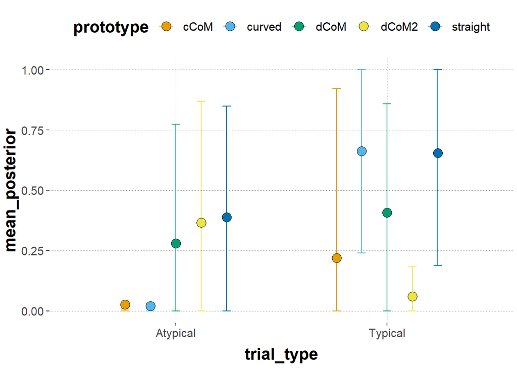

```r
#plotting mean posterior probability of every prototype for each trial type
ggplot(predicted_hypo4) +
   geom_errorbar(aes(x = trial_type, y = mean_posterior, color = prototype,
                    ymin = `95lowerCrI`, ymax = `95higherCrI`),
                width = 0.2,  position = position_dodge(width = 0.6)) +
  geom_point(aes(x = trial_type, y = mean_posterior, fill = prototype),
             size = 4, pch = 21, color = "black", position = position_dodge(0.6))
```

Results: The graph indicates the mean posterior probabilities of the prototypes for each trial type. There are strong differences of the prototypes cCoM and curved between Atypical and Typical, but for the other prototypes the difference is not as big. With dCoM2 it is the other way around: The mean posterior probability is much higher for the Atypical trial type than for the Typical trial type. This could mean that there is a higher probability for some prototypes to differ between the conditions and for ther prototypes this likelihood is lower.

Hypothese 5

```r
capital$RT_log <- log(capital$RT)
capital$RT_log_s = my_scale(capital$RT_log)

#informative priors
prior_hypo5 <- c(
  #priors for all fixed effects (trial_type)
  set_prior("student_t(3, 0, 2)", class = "sigma"),
  #prior for the Intercept
  set_prior("student_t(3, 7, 2)", class = "Intercept"),
  #prior for all SDs including the varying intercepts and slopes
  set_prior("student_t(3, 0, 2)", class = "sd")
)

#by-subject_id varying intercepts and varying
#slope, without slope/intercept correlation
#by-exemplar varying intercept
model_hypo5 = brm(
  RT_log ~ trial_type +
    (trial_type || subject_id)+
    (1 |exemplar),
  control=list(adapt_delta=0.99, max_treedepth=15),
  data = capital,
  prior = prior_hypo5
  )


model_hypo5
```

```
##  Family: gaussian
##   Links: mu = identity; sigma = identity
## Formula: RT_log ~ trial_type + (trial_type || subject_id) + (1 | exemplar)
##    Data: capital (Number of observations: 41)
## Samples: 4 chains, each with iter = 2000; warmup = 1000; thin = 1;
##          total post-warmup samples = 4000
##
## Group-Level Effects:
## ~exemplar (Number of levels: 12)
##               Estimate Est.Error l-95% CI u-95% CI Rhat Bulk_ESS Tail_ESS
## sd(Intercept)     0.32      0.17     0.04     0.70 1.00      699     1078
##
## ~subject_id (Number of levels: 5)
##                       Estimate Est.Error l-95% CI u-95% CI Rhat Bulk_ESS
## sd(Intercept)             0.20      0.22     0.01     0.72 1.00     1020
## sd(trial_typeTypical)     0.17      0.23     0.00     0.67 1.00     1197
##                       Tail_ESS
## sd(Intercept)             1469
## sd(trial_typeTypical)     1559
##
## Population-Level Effects:
##                   Estimate Est.Error l-95% CI u-95% CI Rhat Bulk_ESS Tail_ESS
## Intercept             7.87      0.25     7.40     8.36 1.00     2355     2176
## trial_typeTypical    -0.54      0.28    -1.13    -0.00 1.00     1992     1900
##
## Family Specific Parameters:
##       Estimate Est.Error l-95% CI u-95% CI Rhat Bulk_ESS Tail_ESS
## sigma     0.37      0.06     0.27     0.50 1.00     1290     2383
##
## Samples were drawn using sampling(NUTS). For each parameter, Bulk_ESS
## and Tail_ESS are effective sample size measures, and Rhat is the potential
## scale reduction factor on split chains (at convergence, Rhat = 1).
```

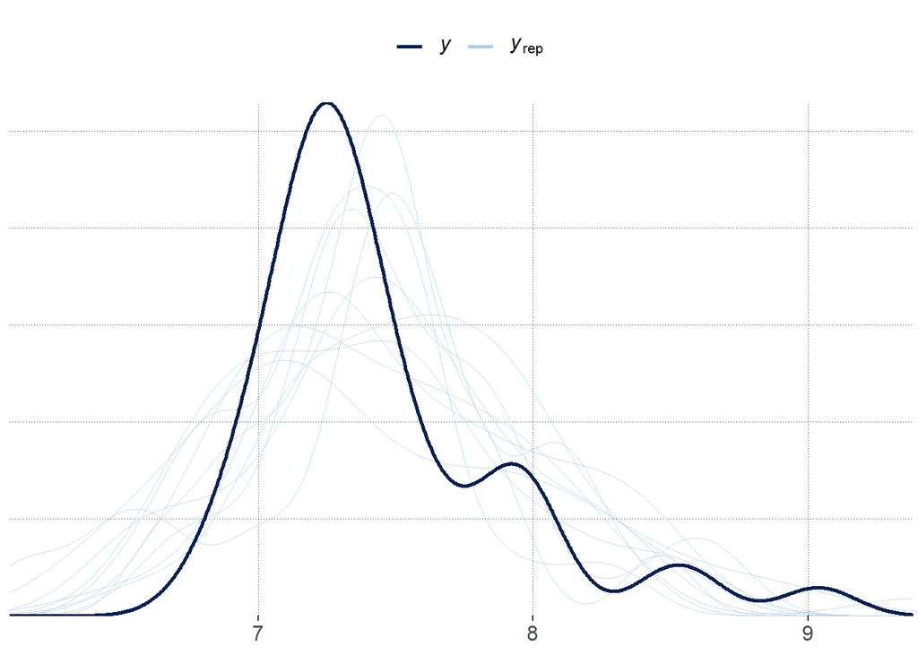

```r
#fitting the model to the actual data
pp_check(model_hypo5)
```

```r
# Extract the posteriors
posteriors5_trial_type <- model_hypo5 %>%
  spread_draws(b_Intercept,
               b_trial_typeTypical) %>%
  # calculate posteriors for each individual level
  mutate(Atypical = b_Intercept,
         Typical = b_Intercept + b_trial_typeTypical) %>%
  select(Atypical, Typical) %>%
  gather(key = "parameter", value = "posterior") %>%
  group_by(parameter) %>%
  summarise(mean_posterior = mean(posterior),
            `95lowerCrI` = HDInterval::hdi(posterior, credMass = 0.90)[1],
            `95higherCrI` = HDInterval::hdi(posterior, credMass = 0.90)[2])

posteriors5_trial_type
```

```
## # A tibble: 2 x 4
##   parameter mean_posterior `95lowerCrI` `95higherCrI`
##   <chr>              <dbl>        <dbl>         <dbl>
## 1 Atypical            7.87         7.48          8.24
## 2 Typical             7.33         6.96          7.67
```

```r
# Extract the posteriors
posteriors5 <- model_hypo5 %>%
  spread_draws(b_trial_typeTypical) %>%
  select(b_trial_typeTypical) %>%
  gather(key = "parameter", value = "posterior")


posteriors5
```

```
## # A tibble: 4,000 x 2
##    parameter           posterior
##    <chr>                   <dbl>
##  1 b_trial_typeTypical    -0.613
##  2 b_trial_typeTypical    -0.376
##  3 b_trial_typeTypical    -0.766
##  4 b_trial_typeTypical    -0.816
##  5 b_trial_typeTypical    -0.756
##  6 b_trial_typeTypical    -0.870
##  7 b_trial_typeTypical    -0.410
##  8 b_trial_typeTypical    -0.786
##  9 b_trial_typeTypical    -0.410
## 10 b_trial_typeTypical    -0.453
## # ... with 3,990 more rows
```

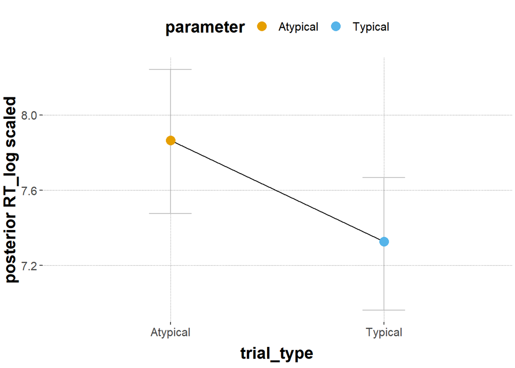

```r
# plot
ggplot(data = posteriors5_trial_type,
       aes(x = parameter, y = mean_posterior,
           color = parameter, fill = parameter)) +
  geom_errorbar(aes(ymin = `95lowerCrI`, ymax = `95higherCrI`),
                width = 0.2, color = "grey") +
  geom_line(aes(group = 1), color = "black") +
  geom_point(size = 4) +
  labs(x = "trial_type",
       y = "posterior RT_log scaled")
```

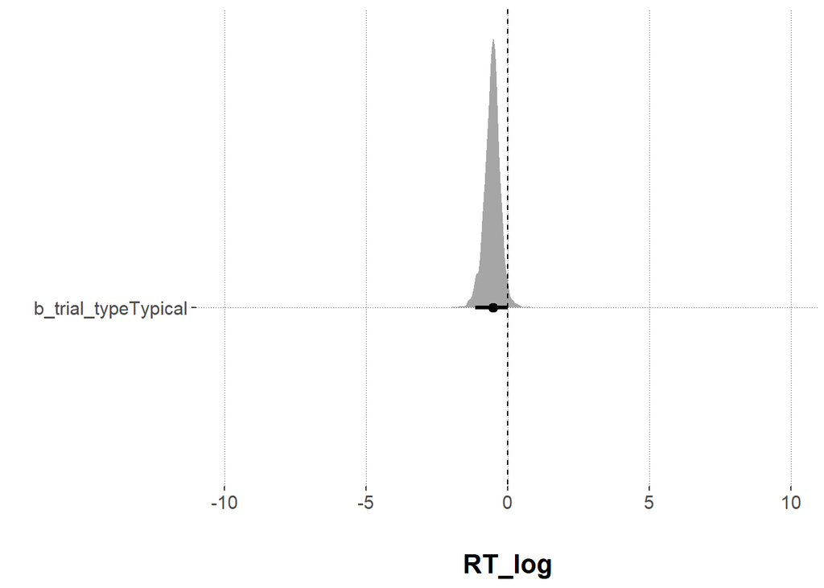

```r
# plot the regression coefficients
  ggplot(posteriors5, aes(x = posterior, y = parameter)) +
    # plot density
    geom_halfeyeh(.width = 0.95) +
    # add axes titles
    xlab("\nRT_log") +
    ylab("") +
    # adjust the x-axis
    scale_x_continuous(limits = c(-10,10)) +
    # add line for the value zero
    geom_segment(x = 0, xend = 0, y = Inf, yend = -Inf,
                 lty = "dashed")
```

Hypothesis 6

```r
capital$initiation_time_s = my_scale(capital$initiation_time)

#informative priors
prior_hypo6 <- c(
  #priors for all fixed effects (trial_type)
  set_prior("student_t(3, 300, 400)", class = "b"),
  #prior for the Intercept
  set_prior("student_t(3, 300,200)", class = "Intercept"),
  #prior for all SDs including the varying intercepts and slopes
  set_prior("student_t(3, 0, 200)", class = "sd"),
  set_prior("student_t(3, 0, 200)", class = "sigma")
)

#by-subject_id varying intercepts and varying
#slope, without slope/intercept correlation
#by-exemplar varying intercept
model_hypo6 = brm(
  initiation_time_s ~ trial_type +
    (trial_type || subject_id)+
    (1 |exemplar),
  control=list(adapt_delta=0.99, max_treedepth=15),
  data = capital,
  prior = prior_hypo6
  )



model_hypo6
```

```
##  Family: gaussian
##   Links: mu = identity; sigma = identity
## Formula: initiation_time_s ~ trial_type + (trial_type || subject_id) + (1 | exemplar)
##    Data: capital (Number of observations: 41)
## Samples: 4 chains, each with iter = 2000; warmup = 1000; thin = 1;
##          total post-warmup samples = 4000
##
## Group-Level Effects:
## ~exemplar (Number of levels: 12)
##               Estimate Est.Error l-95% CI u-95% CI Rhat Bulk_ESS Tail_ESS
## sd(Intercept)     0.87      0.52     0.04     1.98 1.02      285      767
##
## ~subject_id (Number of levels: 5)
##                       Estimate Est.Error l-95% CI u-95% CI Rhat Bulk_ESS
## sd(Intercept)             0.76      0.70     0.07     2.33 1.00     1324
## sd(trial_typeTypical)     0.56      0.60     0.02     1.99 1.00     1327
##                       Tail_ESS
## sd(Intercept)             1647
## sd(trial_typeTypical)     1602
##
## Population-Level Effects:
##                   Estimate Est.Error l-95% CI u-95% CI Rhat Bulk_ESS Tail_ESS
## Intercept             0.68      0.68    -0.60     2.11 1.00     1846     1984
## trial_typeTypical    -0.89      0.78    -2.55     0.53 1.00     1366     1690
##
## Family Specific Parameters:
##       Estimate Est.Error l-95% CI u-95% CI Rhat Bulk_ESS Tail_ESS
## sigma     0.74      0.15     0.51     1.06 1.01      419     1884
##
## Samples were drawn using sampling(NUTS). For each parameter, Bulk_ESS
## and Tail_ESS are effective sample size measures, and Rhat is the potential
## scale reduction factor on split chains (at convergence, Rhat = 1).
```

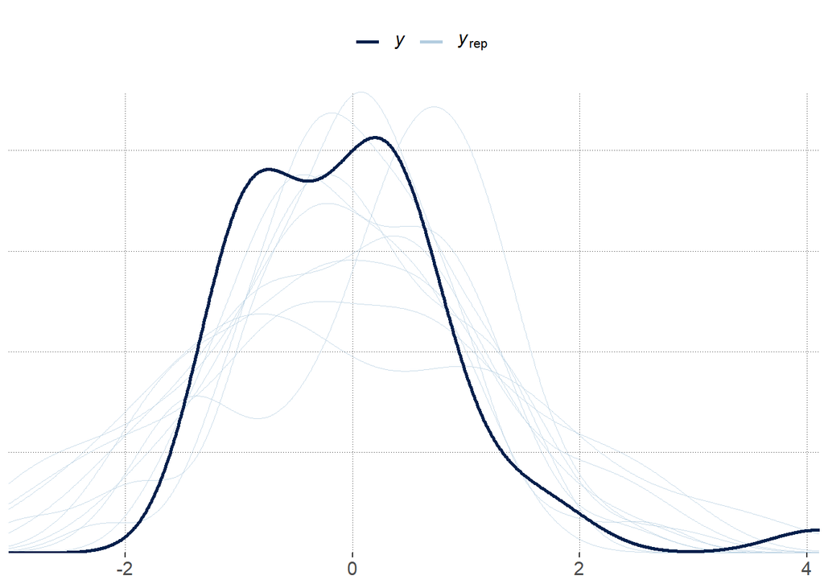

```r
#fitting the model to the actual data
pp_check(model_hypo6)
```

```r
# Extract the posteriors
posteriors6_trial_type <- model_hypo6 %>%
  spread_draws(b_Intercept,
               b_trial_typeTypical) %>%
  # calculate posteriors for each individual level
  mutate(Atypical = b_Intercept,
         Typical = b_Intercept + b_trial_typeTypical) %>%
  select(Atypical, Typical) %>%
  gather(key = "parameter", value = "posterior") %>%
  group_by(parameter) %>%
  summarise(mean_posterior = mean(posterior),
            `95lowerCrI` = HDInterval::hdi(posterior, credMass = 0.90)[1],
            `95higherCrI` = HDInterval::hdi(posterior, credMass = 0.90)[2])

posteriors6_trial_type
```

```
## # A tibble: 2 x 4
##   parameter mean_posterior `95lowerCrI` `95higherCrI`
##   <chr>              <dbl>        <dbl>         <dbl>
## 1 Atypical           0.678       -0.332         1.75
## 2 Typical           -0.214       -1.26          0.817
```

```r
# Extract the posteriors
posteriors6 <- model_hypo6 %>%
  spread_draws(b_trial_typeTypical) %>%
  select(b_trial_typeTypical) %>%
  gather(key = "parameter", value = "posterior")


posteriors6
```

```
## # A tibble: 4,000 x 2
##    parameter           posterior
##    <chr>                   <dbl>
##  1 b_trial_typeTypical    -0.441
##  2 b_trial_typeTypical    -0.344
##  3 b_trial_typeTypical    -0.241
##  4 b_trial_typeTypical    -1.65
##  5 b_trial_typeTypical    -2.97
##  6 b_trial_typeTypical    -1.87
##  7 b_trial_typeTypical     0.482
##  8 b_trial_typeTypical     0.714
##  9 b_trial_typeTypical     0.183
## 10 b_trial_typeTypical     1.69
## # ... with 3,990 more rows
```

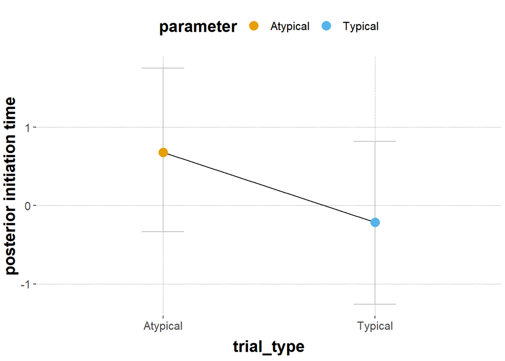

```r
# plot
ggplot(data = posteriors6_trial_type,
       aes(x = parameter, y = mean_posterior,
           color = parameter, fill = parameter)) +
  geom_errorbar(aes(ymin = `95lowerCrI`, ymax = `95higherCrI`),
                width = 0.2, color = "grey") +
  geom_line(aes(group = 1), color = "black") +
  geom_point(size = 4) +
  labs(x = "trial_type",
       y = "posterior initiation time")
```

[figure not shown]

```r
# plot the regression coefficients
  ggplot(posteriors6, aes(x = posterior, y = parameter)) +
    # plot density
    geom_halfeyeh(.width = 0.95) +
    # add axes titles
    xlab("\nInitiation Time") +
    ylab("") +
    # adjust the x-axis
    scale_x_continuous(limits = c(-5000,5000)) +
    # add line for the value zero
    geom_segment(x = 0, xend = 0, y = Inf, yend = -Inf,
                 lty = "dashed")
```

Hypothese 7

```r
capital$traveledDistance_abs <- abs(capital$traveledDistance)
capital$traveledDistance_abs_s <- my_scale(capital$traveledDistance_abs)

#informative prior
prior_hypo7 <- c(
  #prior for the Intercept
  set_prior("student_t(3, 10,15)", class = "Intercept"),
  #prior for all SDs including the varying intercepts and slopes
  set_prior("student_t(3, 0, 15)", class = "sd"),
  set_prior("student_t(3, 0, 15)", class = "sigma")
)

#by-subject_id varying intercepts and varying
#slope, without slope/intercept correlation
#by-exemplar varying intercept
model_hypo7 = brm(
  traveledDistance_abs_s ~ trial_type +
    (trial_type || subject_id)+
    (1 |exemplar),
  control=list(adapt_delta=0.99, max_treedepth=15),
  data = capital,
  prior = prior_hypo7
  )


model_hypo7
```

```
##  Family: gaussian
##   Links: mu = identity; sigma = identity
## Formula: traveledDistance_abs_s ~ trial_type + (trial_type || subject_id) + (1 | exemplar)
##    Data: capital (Number of observations: 41)
## Samples: 4 chains, each with iter = 2000; warmup = 1000; thin = 1;
##          total post-warmup samples = 4000
##
## Group-Level Effects:
## ~exemplar (Number of levels: 12)
##               Estimate Est.Error l-95% CI u-95% CI Rhat Bulk_ESS Tail_ESS
## sd(Intercept)     0.49      0.35     0.03     1.32 1.01      622     1443
##
## ~subject_id (Number of levels: 5)
##                       Estimate Est.Error l-95% CI u-95% CI Rhat Bulk_ESS
## sd(Intercept)             0.27      0.34     0.01     1.14 1.00     1722
## sd(trial_typeTypical)     0.30      0.36     0.01     1.19 1.00     1744
##                       Tail_ESS
## sd(Intercept)             1952
## sd(trial_typeTypical)     1907
##
## Population-Level Effects:
##                   Estimate Est.Error l-95% CI u-95% CI Rhat Bulk_ESS Tail_ESS
## Intercept             1.08      0.42     0.29     1.94 1.00     2177     2465
## trial_typeTypical    -1.41      0.51    -2.48    -0.40 1.00     2159     1640
##
## Family Specific Parameters:
##       Estimate Est.Error l-95% CI u-95% CI Rhat Bulk_ESS Tail_ESS
## sigma     0.79      0.12     0.59     1.06 1.00     1345     2380
##
## Samples were drawn using sampling(NUTS). For each parameter, Bulk_ESS
## and Tail_ESS are effective sample size measures, and Rhat is the potential
## scale reduction factor on split chains (at convergence, Rhat = 1).
```

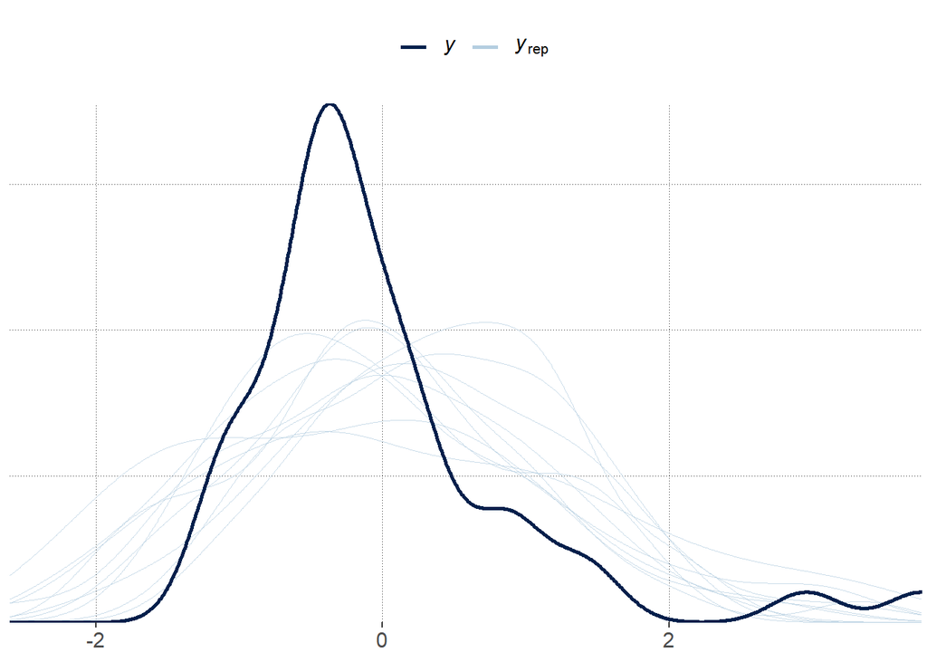

```r
#fitting the model to the actual data
pp_check(model_hypo7)
```

```r
# Extract the posteriors
posteriors7_trial_type <- model_hypo7 %>%
  spread_draws(b_Intercept,
               b_trial_typeTypical) %>%
  # calculate posteriors for each individual level
  mutate(Atypical = b_Intercept,
         Typical = b_Intercept + b_trial_typeTypical) %>%
  select(Atypical, Typical) %>%
  gather(key = "parameter", value = "posterior") %>%
  group_by(parameter) %>%
  summarise(mean_posterior = mean(posterior),
            `95lowerCrI` = HDInterval::hdi(posterior, credMass = 0.90)[1],
            `95higherCrI` = HDInterval::hdi(posterior, credMass = 0.90)[2])

posteriors7_trial_type
```

```
## # A tibble: 2 x 4
##   parameter mean_posterior `95lowerCrI` `95higherCrI`
##   <chr>              <dbl>        <dbl>         <dbl>
## 1 Atypical           1.08         0.431         1.75
## 2 Typical           -0.330       -0.922         0.288
```

```r
# Extract the posteriors
posteriors7 <- model_hypo7 %>%
  spread_draws(b_trial_typeTypical) %>%
  select(b_trial_typeTypical) %>%
  gather(key = "parameter", value = "posterior")


posteriors7
```

```
## # A tibble: 4,000 x 2
##    parameter           posterior
##    <chr>                   <dbl>
##  1 b_trial_typeTypical    -0.958
##  2 b_trial_typeTypical    -1.45
##  3 b_trial_typeTypical    -1.20
##  4 b_trial_typeTypical    -1.32
##  5 b_trial_typeTypical    -1.15
##  6 b_trial_typeTypical    -1.53
##  7 b_trial_typeTypical    -0.874
##  8 b_trial_typeTypical    -1.72
##  9 b_trial_typeTypical    -1.43
## 10 b_trial_typeTypical    -1.18
## # ... with 3,990 more rows
```

```r
posterior7_agg <- posteriors7 %>%
  mutate(mean_posterior = mean(posterior))

posterior7_agg
```

```
## # A tibble: 4,000 x 3
##    parameter           posterior mean_posterior
##    <chr>                   <dbl>          <dbl>
##  1 b_trial_typeTypical    -0.958          -1.41
##  2 b_trial_typeTypical    -1.45           -1.41
##  3 b_trial_typeTypical    -1.20           -1.41
##  4 b_trial_typeTypical    -1.32           -1.41
##  5 b_trial_typeTypical    -1.15           -1.41
##  6 b_trial_typeTypical    -1.53           -1.41
##  7 b_trial_typeTypical    -0.874          -1.41
##  8 b_trial_typeTypical    -1.72           -1.41
##  9 b_trial_typeTypical    -1.43           -1.41
## 10 b_trial_typeTypical    -1.18           -1.41
## # ... with 3,990 more rows
```

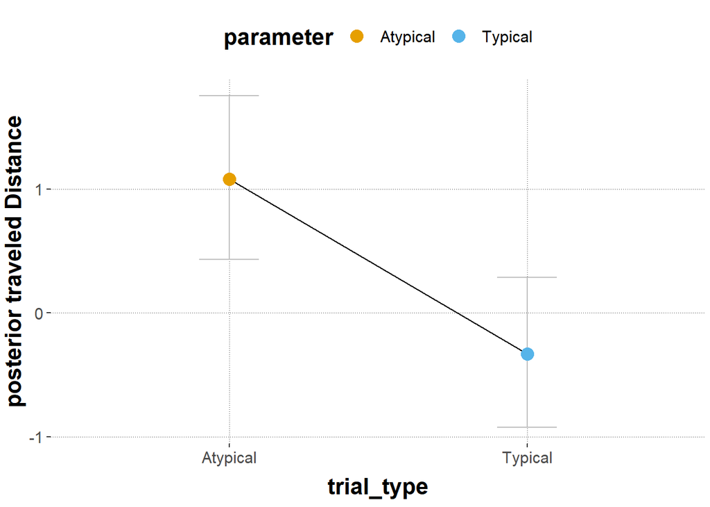

```r
# plot
ggplot(data = posteriors7_trial_type,
       aes(x = parameter, y = mean_posterior,
           color = parameter, fill = parameter)) +
  geom_errorbar(aes(ymin = `95lowerCrI`, ymax = `95higherCrI`),
                width = 0.2, color = "grey") +
  geom_line(aes(group = 1), color = "black") +
  geom_point(size = 4) +
  labs(x = "trial_type",
       y = "posterior traveled Distance")
```

[figure not shown]

```r
# plot the regression coefficients
  ggplot(posteriors7, aes(x = posterior, y = parameter)) +
    # plot density
    geom_halfeyeh(.width = 0.95) +
    # add axes titles
    xlab("\n Traveled Distance") +
    ylab("") +
    # adjust the x-axis
    scale_x_continuous(limits = c(-500,500)) +
    # add line for the value zero
    geom_segment(x = 0, xend = 0, y = Inf, yend = -Inf,
                 lty = "dashed")
```

```r
#computing evidential ratio and posterior probability
hypothesis(model_hypo7, "trial_typeTypical > -42.19")
```

```
## Hypothesis Tests for class b:
##                 Hypothesis Estimate Est.Error CI.Lower CI.Upper Evid.Ratio
## 1 (trial_typeTypica... > 0    40.78      0.51     39.9    41.57        Inf
##   Post.Prob Star
## 1         1    *
## ---
## 'CI': 90%-CI for one-sided and 95%-CI for two-sided hypotheses.
## '*': For one-sided hypotheses, the posterior probability exceeds 95%;
## for two-sided hypotheses, the value tested against lies outside the 95%-CI.
## Posterior probabilities of point hypotheses assume equal prior probabilities.
```